# Sports Analytics for EPL Report

## Contributors:

- Ghizlane Rehioui
- Yashwanth Reddy T
- Taahaa Dawe
- Dhruv Gupta

# Introduction

In the world of football analysis, data is the key to unlocking the game's secrets. This report focuses on our use of data from the reputable FBRef website (https://fbref.com/en/) to delve into the Premier League, covering the seasons from 2016-17 to 2023-24.

Our analysis goes beyond traditional points tables, delving into team performance metrics and shooting statistics for each match. With this extensive dataset, we aim to uncover the strategies, player performance, and dynamics that have shaped Premier League football.

In the following pages, we will explore trends, anomalies, and insights from seven seasons of Premier League action. This report serves as a valuable resource for football enthusiasts and analysts alike, highlighting the power of data in understanding the beautiful game. Join us on this data-driven journey through the heart of Premier League football!

# Column Description

- 'date': Date of the match
- 'time': Time of match
- 'comp': Competition name
- 'round': Matchweek number
- 'day': Day of the week
- 'venue': Where the game is played (Away or Home)
- 'result': W for Win, D for Draw, and L for Loss
- 'goals_scored': Number of goals scored
- 'goals_conceded': Number of goals conceded
- 'opponent': Opponent team name
- 'expected_goals': Expected goals to score
- 'expected_assists': Expected assists provided
- 'possession': Duration for which the team had the ball possession
- 'attendance': Count of audience
- 'captain': Captain of team
- 'formation': Team formation
- 'referee': Referee name
- 'shots': Shots taken by team
- 'shots_on_target': Shots on target by team
- 'avg_shot_distance': Average shot distance
- 'freekicks': Freekicks taken
- 'penaltykicks': Penalties taken
- 'penaltykicks_opponent': Penalties given to opponent
- 'season': Season year
- 'team': Team

# Statement of the questions of interest

1. Do the teams perform better at home or away?
2. Which team are in the top 5% based on their wins?
3. Total goals per season for the 5 best teams and their average in each season
4. Identifying overperforming football teams based on goals scored and expected goals (xG)

First and foremost, before doing any analysis, it is important to acknowledge that we might encounter some biases in our analysis.

# Possible sources of bias

## Biases from web scraped data

Web scraping may be a great way to quickly access real time data. However, we might run into issues such as the untimely updates of important information, which could potentially lead to misinterpretations. Another possible source of bias would be to ask if the period between 2017-2023 is truly representative of the teams' performance or success.

## Biases related to Football as a game

Football is a highly *unpredictable* game. Due to the low scoring nature of the sport, a 'less qualified' team can easily win against a much more talented team. It is also easier to catch up in terms of points. Additionally, a simple mistake from a defender or keeper may be an easy opportunity for the opponent to score and win a match, especially during extra time.

In addition to the low scoring nature of Football, Referee bias is a popular theory among Football fans, hypothesizing that referees play a huge role in the match, either favoring for or against a team. In fact, some fans strongly believe that that some referees turn a blind eye on some penalties, which could have made some teams easily qualify given that the opponent's team does not have a good goalkeeper. Other biases include seasonal bias or team/player bias related to the scouted or players involved in the match.

## Choice of metrics - Measurement Bias

The choice of the metrics, i.e. the domain or industry knowledge, that drive our analysis or conclusions is crucial. In other words, the standardized matrics or parameters used in Football Analytics should be respected and using other metrics may lead to misinterpretations.

## Omitted variable bias

In our analysis, we might fall into ommitted variable bias where we disregard some critical attributes that influence the outcome are missing.

```python
!pip install pandasql
```

```python
# Import the necessary libraries
import pandas as pd
import numpy as np
import matplotlib.pyplot as plt
import seaborn as sb
from pandasql import sqldf
```

# Data scraping code

The data utilized for this analysis was scraped from the FBRef website (https://fbref.com/en/), a reputable source for football statistics and history. The focus of this project was on gathering and analyzing individual team match data from the Premier League, spanning from the 2016-17 season to the current season, 2023-24. In addition to the points table information, we also retrieved crucial shooting statistics for each team in every match from the shooting table. This comprehensive dataset allows for a detailed exploration of team performance metrics and shooting proficiency within the Premier League during the specified timeframe.

**NOTE: The following section contains the scraping code as a markdown because scraping takes more than one hour.**

### Scraping page with requests

import requests standings_url = "https://fbref.com/en/comps/9/Premier-League-Stats"

- Download the page data = requests.get(standings_url)

print(data) # The response should be '200'. If it gives '429', then try again later as it is rate limiting.

### Parsing HTML links with BeautifulSoup

from bs4 import BeautifulSoup

import time

# Giving the browser time to complete the action and then come up with new sourcecode before reading it using beautifulsoup

soup = BeautifulSoup(data.text)

standings_table = soup.select('table.stats_table')[0]

links = standings_table.find_all('a')

links = [l.get("href") for l in links]

links = [l for l in links if '/squads/' in l]

team_urls = [f"https://fbref.com{l}" for l in links]

### Extracting match stats using pandas and requests

data = requests.get(team_urls[0])

import pandas as pd

matches = pd.read_html(data.text, match="Scores & Fixtures")[0]

### Getting match shooting stats with requests and pandas

soup = BeautifulSoup(data.text)

links = soup.find_all('a')

links = [l.get("href") for l in links]

links = [l for l in links if l and 'all_comps/shooting/' in l]

data = requests.get(f"https://fbref.com{links[0]}")

shooting = pd.read_html(data.text, match="Shooting")[0]

shooting.head()

# Cleaning and merging scraped data with pandas

shooting.columns = shooting.columns.droplevel()

team_data = matches.merge(shooting[["Date", "Sh", "SoT", "Dist", "FK", "PK", "PKatt"]], on="Date")

team_data.head()

### Scraping data for multiple seasons and teams with a loop

from datetime import datetime

current_year = datetime.now().year

years = list(range(current_year, 2016, -1))

all_matches = []

years #The year'2016' is actually the season '2015-2016'. We use this everywhere which makes working with the data easier.

standings_url = "https://fbref.com/en/comps/9/Premier-League-Stats"

for year in years:

```
data = requests.get(standings_url)

soup = BeautifulSoup(data.text)

standings_table = soup.select('table.stats_table')[0]

links = [l.get("href") for l in standings_table.find_all('a')]

links = [l for l in links if '/squads/' in l]

team_urls = [f"https://fbref.com{l}" for l in links]

previous_season = soup.select("a.prev")[0].get("href")

standings_url = f"https://fbref.com{previous_season}"

for team_url in team_urls:

    team_name = team_url.split("/")[-1].replace("-Stats", "").replace("-", " ")

    data = requests.get(team_url)

    matches = pd.read_html(data.text, match="Scores & Fixtures")[0]

    soup = BeautifulSoup(data.text)

    links = [l.get("href") for l in soup.find_all('a')]

    links = [l for l in links if l and 'all_comps/shooting/' in l]

    data = requests.get(f"https://fbref.com{links[0]}")

    shooting = pd.read_html(data.text, match="Shooting")[0]

    shooting.columns = shooting.columns.droplevel()

    try:

        team_data = matches.merge(shooting[["Date", "Sh", "SoT", "Dist", "FK", "PK", "PKatt"]], on="Date")
    except ValueError:

        continue

    team_data = team_data[team_data["Comp"] == "Premier League"]

    team_data["Season"] = year

    team_data["Team"] = team_name

    all_matches.append(team_data)

    time.sleep(1)
```

len(all_matches)

match_df = pd.concat(all_matches) # Combining the individual dataframes into a single dataframe

### Data cleaning before converting to csv

match_df.columns = [c.lower() for c in match_df.columns]

match_df.head()

match_df.shape

match_df["team"].value_counts()

match_df.isnull().sum()

match_df.columns

match_df.rename(columns = {'gf':'goals_scored', 'ga':'goals_conceded', 'xg':'expected_goals', 'xga':'expected_assists', 'poss':'possession', 'sh':'shots', 'sot':'shots_on_target', 'dist':'avg_shot_distance', 'fk':'freekicks', 'pk':'penaltykicks', 'pkatt':'penaltykicks_opponent'}, inplace=True )

match_df.head()

match_df.drop(columns=['notes', 'match report'], inplace=True)

match_df.isnull().sum()

match_df.dtypes

match_df[["goals_scored", "goals_conceded"]] = match_df[["goals_scored", "goals_conceded"]].astype(int)

match_df.dtypes

match_df

match_df.to_csv("matches.csv")

### End Of Web Scrapping Code

# Data Cleaning

```python
# Read in the data
df = pd.read_csv('matches.csv')
df.head(3)
```

|  | Unnamed: 0 | date | time | comp | round | day | venue | result | goals_scored | goals_conceded | ... | formation | referee | shots | shots_on_target | avg_shot_distance | freekicks | penaltykicks | penaltykicks_opponent | season | team |
| --- | --- | --- | --- | --- | --- | --- | --- | --- | --- | --- | --- | --- | --- | --- | --- | --- | --- | --- | --- | --- | --- |
| 0 | 1 | 2023-08-11 | 20:00 | Premier League | Matchweek 1 | Fri | Away | W | 3 | 0 | ... | 4-2-3-1 | Craig Pawson | 17.0 | 8.0 | 13.9 | 0.0 | 0.0 | 0.0 | 2023 | Manchester City |
| 1 | 3 | 2023-08-19 | 20:00 | Premier League | Matchweek 2 | Sat | Home | W | 1 | 0 | ... | 4-2-3-1 | Robert Jones | 14.0 | 4.0 | 17.9 | 0.0 | 0.0 | 0.0 | 2023 | Manchester City |
| 2 | 4 | 2023-08-27 | 14:00 | Premier League | Matchweek 3 | Sun | Away | W | 2 | 1 | ... | 4-2-3-1 | Jarred Gillett | 29.0 | 9.0 | 17.3 | 2.0 | 0.0 | 1.0 | 2023 | Manchester City |

3 rows × 26 columns

```python
df.columns
```

```
Index(['Unnamed: 0', 'date', 'time', 'comp', 'round', 'day', 'venue', 'result',
       'goals_scored', 'goals_conceded', 'opponent', 'expected_goals',
       'expected_assists', 'possession', 'attendance', 'captain', 'formation',
       'referee', 'shots', 'shots_on_target', 'avg_shot_distance', 'freekicks',
       'penaltykicks', 'penaltykicks_opponent', 'season', 'team'],
      dtype='object')
```

```python
df.drop(['Unnamed: 0'], axis=1, inplace= True)
df.head(3)
```

|  | date | time | comp | round | day | venue | result | goals_scored | goals_conceded | opponent | ... | formation | referee | shots | shots_on_target | avg_shot_distance | freekicks | penaltykicks | penaltykicks_opponent | season | team |
| --- | --- | --- | --- | --- | --- | --- | --- | --- | --- | --- | --- | --- | --- | --- | --- | --- | --- | --- | --- | --- | --- |
| 0 | 2023-08-11 | 20:00 | Premier League | Matchweek 1 | Fri | Away | W | 3 | 0 | Burnley | ... | 4-2-3-1 | Craig Pawson | 17.0 | 8.0 | 13.9 | 0.0 | 0.0 | 0.0 | 2023 | Manchester City |
| 1 | 2023-08-19 | 20:00 | Premier League | Matchweek 2 | Sat | Home | W | 1 | 0 | Newcastle Utd | ... | 4-2-3-1 | Robert Jones | 14.0 | 4.0 | 17.9 | 0.0 | 0.0 | 0.0 | 2023 | Manchester City |
| 2 | 2023-08-27 | 14:00 | Premier League | Matchweek 3 | Sun | Away | W | 2 | 1 | Sheffield Utd | ... | 4-2-3-1 | Jarred Gillett | 29.0 | 9.0 | 17.3 | 2.0 | 0.0 | 1.0 | 2023 | Manchester City |

3 rows × 25 columns

# Exploratory Data Analysis

## 1. Goals Scored Home vs. Away

```python
jj= df["team"].unique().tolist()
all_goals = []
new_df ={}
for i in range(len(jj)):
  all_goals.append(df[df["team"].str.contains(jj[i])]["goals_scored"].sum())

new_df={"Teams": jj ,"all_goals": all_goals}

new_df = pd.DataFrame(new_df)
new_df.head()
```

|  | Teams | all_goals |
| --- | --- | --- |
| 0 | Manchester City | 595 |
| 1 | Liverpool | 510 |
| 2 | Brighton and Hove Albion | 280 |
| 3 | Tottenham Hotspur | 424 |
| 4 | Arsenal | 418 |

```python
df[df["team"].str.contains(jj[0])]["goals_scored"].sum()
```

```
595
```

```python
df[df["venue"].str.contains(jj[0])]["goals_scored"].sum()
```

```
0
```

```python
Away_matches = df[df["venue"].str.contains("Away")]
home_matches = df[df["venue"].str.contains("Home")]
```

```python
all_goals = []
Away_goals = []
Home_goals = []
new_df ={}
for i in range(len(jj)):
  all_goals.append(df[df["team"].str.contains(jj[i])]["goals_scored"].sum())
  Away_goals.append(Away_matches[Away_matches["team"].str.contains(jj[i])]["goals_scored"].sum())
  Home_goals.append(home_matches[home_matches["team"].str.contains(jj[i])]["goals_scored"].sum())

new_df={"Teams": jj ,"Away": Away_goals,"Home_goals":Home_goals ,"all_goals": all_goals}

new_df = pd.DataFrame(new_df)
new_df.sort_values(by= "Away", ascending= False, inplace= True)
```

```python
new_df.sort_values(by ="all_goals", ascending=False, inplace= True)
```

```python
new_df.head()
```

|  | Teams | Away | Home_goals | all_goals |
| --- | --- | --- | --- | --- |
| 0 | Manchester City | 251 | 344 | 595 |
| 1 | Liverpool | 225 | 285 | 510 |
| 3 | Tottenham Hotspur | 200 | 224 | 424 |
| 4 | Arsenal | 165 | 253 | 418 |
| 8 | Manchester United | 172 | 222 | 394 |

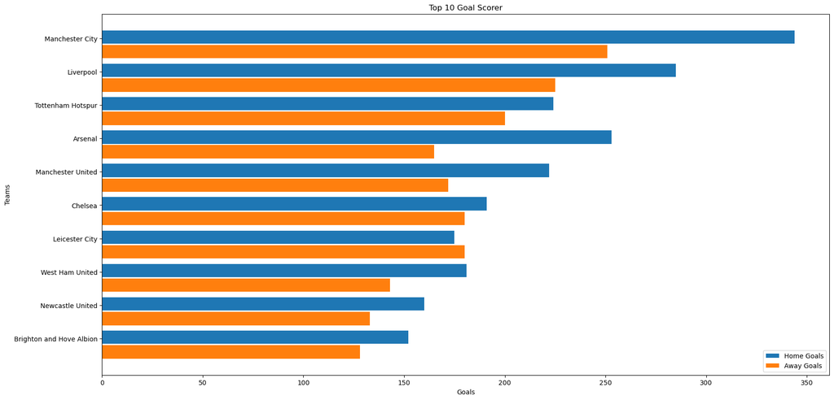

```python
plt.figure(figsize=(20,10))

Teams = new_df["Teams"].head(10).tolist()
Away_goals= new_df["Away"].head(10).tolist()
Home_goals= new_df["Home_goals"].head(10).tolist()

X_axis = np.arange(len(Teams))

plt.barh(X_axis-.04, Home_goals, 0.4, label = 'Home Goals')
plt.barh(X_axis+0.4, Away_goals, 0.4, label = 'Away Goals')
plt.yticks( X_axis, Teams)
plt.xlabel("Goals")
plt.ylabel("Teams")
plt.title("Top 10 Goal Scorer")
plt.gca().invert_yaxis()
plt.legend()
plt.show()
```

## 2. Finding the best 5 teams across the seasons

```python
#df = pd.read_csv(r"matches.csv")
df.columns
```

```
Index(['date', 'time', 'comp', 'round', 'day', 'venue', 'result',
       'goals_scored', 'goals_conceded', 'opponent', 'expected_goals',
       'expected_assists', 'possession', 'attendance', 'captain', 'formation',
       'referee', 'shots', 'shots_on_target', 'avg_shot_distance', 'freekicks',
       'penaltykicks', 'penaltykicks_opponent', 'season', 'team'],
      dtype='object')
```

```python
df.head()
```

|  | date | time | comp | round | day | venue | result | goals_scored | goals_conceded | opponent | ... | formation | referee | shots | shots_on_target | avg_shot_distance | freekicks | penaltykicks | penaltykicks_opponent | season | team |
| --- | --- | --- | --- | --- | --- | --- | --- | --- | --- | --- | --- | --- | --- | --- | --- | --- | --- | --- | --- | --- | --- |
| 0 | 2023-08-11 | 20:00 | Premier League | Matchweek 1 | Fri | Away | W | 3 | 0 | Burnley | ... | 4-2-3-1 | Craig Pawson | 17.0 | 8.0 | 13.9 | 0.0 | 0.0 | 0.0 | 2023 | Manchester City |
| 1 | 2023-08-19 | 20:00 | Premier League | Matchweek 2 | Sat | Home | W | 1 | 0 | Newcastle Utd | ... | 4-2-3-1 | Robert Jones | 14.0 | 4.0 | 17.9 | 0.0 | 0.0 | 0.0 | 2023 | Manchester City |
| 2 | 2023-08-27 | 14:00 | Premier League | Matchweek 3 | Sun | Away | W | 2 | 1 | Sheffield Utd | ... | 4-2-3-1 | Jarred Gillett | 29.0 | 9.0 | 17.3 | 2.0 | 0.0 | 1.0 | 2023 | Manchester City |
| 3 | 2023-09-02 | 15:00 | Premier League | Matchweek 4 | Sat | Home | W | 5 | 1 | Fulham | ... | 4-2-3-1 | Michael Oliver | 6.0 | 4.0 | 14.8 | 0.0 | 1.0 | 1.0 | 2023 | Manchester City |
| 4 | 2023-09-16 | 15:00 | Premier League | Matchweek 5 | Sat | Away | W | 3 | 1 | West Ham | ... | 4-2-3-1 | Andy Madley | 29.0 | 13.0 | 16.4 | 1.0 | 0.0 | 0.0 | 2023 | Manchester City |

5 rows × 25 columns

### Description

Every season, bottom 3 teams are relegated (demoted) to a lower level and 3 new teams from the lower league are promoted to the premier league.

Liverpool won the last season but which team is the best when it comes to overall seasons? Let's find out

# Grouping Data based on Team

```python
#query1 = "SELECT team, COUNT(*) as Matches_Played FROM df GROUP BY team ORDER BY COUNT(*) DESC;"
query1 = "SELECT team, count(*) as Matches_Played FROM df Group By team order by count(*) desc"
result1 = sqldf(query1)
#result1
```

# Finding total matches won by each team

```python
query2 = "SELECT team, count(*) as Matches_Won FROM df where result ='W' Group By team order by count(*) desc"
result2 = sqldf(query2)
result2
```

|  | team | Matches_Won |
| --- | --- | --- |
| 0 | Manchester City | 180 |
| 1 | Liverpool | 155 |
| 2 | Manchester United | 125 |
| 3 | Tottenham Hotspur | 124 |
| 4 | Arsenal | 124 |
| 5 | Chelsea | 114 |
| 6 | Leicester City | 88 |
| 7 | West Ham United | 84 |
| 8 | Newcastle United | 82 |
| 9 | Everton | 78 |
| 10 | Crystal Palace | 72 |
| 11 | Brighton and Hove Albion | 71 |
| 12 | Wolverhampton Wanderers | 70 |
| 13 | Aston Villa | 60 |
| 14 | Southampton | 58 |
| 15 | Burnley | 57 |
| 16 | Bournemouth | 44 |
| 17 | Watford | 39 |
| 18 | Leeds United | 34 |
| 19 | Fulham | 29 |
| 20 | Brentford | 29 |
| 21 | Sheffield United | 21 |
| 22 | Huddersfield Town | 12 |
| 23 | West Bromwich Albion | 11 |
| 24 | Nottingham Forest | 11 |
| 25 | Norwich City | 10 |
| 26 | Cardiff City | 10 |
| 27 | Swansea City | 8 |
| 28 | Stoke City | 7 |

# Joining Data to get combined result

```python
query3 = 'SELECT a.team as Team, a.Matches_Played, b.Matches_Won FROM result1 a join result2 b on a.team=b.team'
result3 = sqldf(query3)
```

```python
result3['Win Percentage'] = round(result3['Matches_Won']/result3['Matches_Played'],2)*100
```

# Fetching Top 5 clubs

```python
result3 = result3.sort_values(by=['Win Percentage'],ascending=False).head(5)
```

```python
result3
```

|  | Team | Matches_Played | Matches_Won | Win Percentage |
| --- | --- | --- | --- | --- |
| 4 | Manchester City | 234 | 180 | 77.0 |
| 5 | Liverpool | 234 | 155 | 66.0 |
| 3 | Manchester United | 234 | 125 | 53.0 |
| 10 | Arsenal | 234 | 124 | 53.0 |
| 1 | Tottenham Hotspur | 234 | 124 | 53.0 |

# Plotting Graph

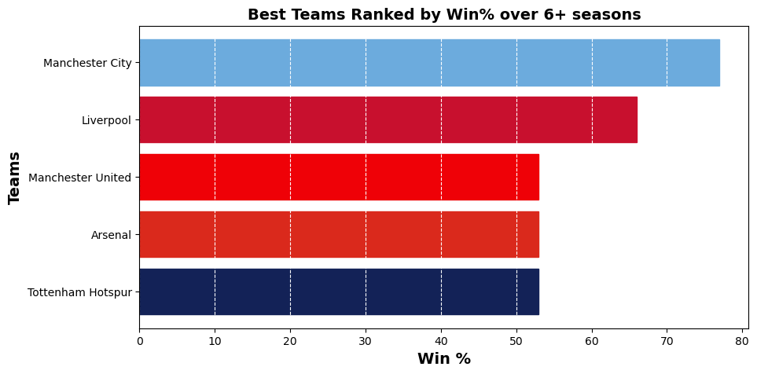

```python
fig = plt.figure(figsize = (10, 5))

# creating the bar plot
barlist = plt.barh(result3['Team'], result3['Win Percentage'], color ='blue'
                  # ,width = 0.3
                  )

barlist[0].set_color('#6CABDD')
barlist[1].set_color('#C8102E')
barlist[2].set_color('#EF0107')
barlist[3].set_color('#DA291C')
barlist[4].set_color('#132257')

#plt.rcParams['axes.facecolor'] = '#FDE5B4'

plt.xlabel("Win %",fontweight='bold',fontsize=14.0)
#plt.xticks(rotation='vertical')
plt.ylabel("Teams",fontweight='bold',fontsize=14.0)
plt.title("Best Teams Ranked by Win% over 6+ seasons",fontweight='bold',fontsize=14.0)
plt.grid(axis='x',color = 'white', linestyle = '--')
plt.gca().invert_yaxis()
plt.show()
```

## 3. Seasonally scored goals:

```python
# Get the Top 10 teams and see their performance with respect to time
ttl_goals_per_teams = df.groupby('team')['goals_scored'].sum().reset_index(name='count').sort_values(by='count', ascending=False)
ttl_goals_per_teams = ttl_goals_per_teams.reset_index()
top = list(ttl_goals_per_teams['team'][:5])

# Dataframe of only top 5
df2 = df[df['team'].isin(top)]

# Dataframe of sum of goals_scored of only top 5 per season
t1 = df2.groupby(['team', 'season'])['goals_scored'].sum().reset_index()

# Dataframe of avg of goals_scored of only top 5 per season
t2 = df2.groupby(['team', 'season'])['goals_scored'].mean().reset_index()

# Dataframe of avg of goals_scored of only top 5 per season
t3 = df2.groupby(['team', 'round', 'season'])['goals_scored'].mean().reset_index()
```

> **Note 1:** The 2023 season is not over yet, and it being shown on the graph might be misleading (as in the teams' seasonal goal scores are getting worse) It might be more maeningful to look at average scored goals to include 2023 in our analysis as well.

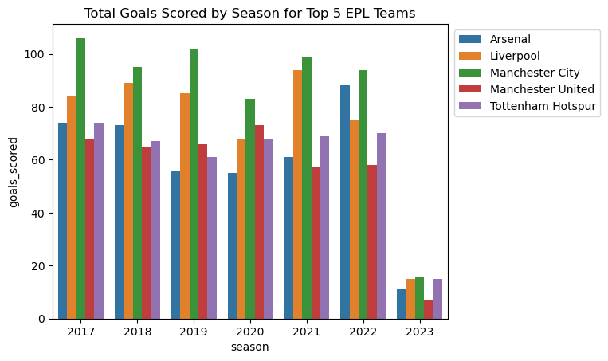

```python
### Sum of seasonally scored goals for top 5:
sb.barplot(x = t1["season"], y = t1["goals_scored"], hue = "team", data= t1)
plt.title('Total Goals Scored by Season for Top 5 EPL Teams')
plt.legend(loc='upper right', bbox_to_anchor=(1.4, 1))
plt.show()
```

### Description

Arsenal and Tottenham Hotspur's performance are slowly increasing over time between 2019 and 2022. Manchester United's performance is increasing from 2019 by a bit in 2020 then decreasing in 2021 to become about the same in 2022 Liverpool's seasonal goal scores are decreasing from 2019 to 2020, then increasing in 2021, and decreasing once again in 2022.

Overall, it seems that Manchester City, compared to the other top 5 teams, is able to maintain the highest seasonal goals scored from one year to the next.

> **Note 2:** We know that goal scores are not typically a float type but for the sake of comparability between 2023 and previous years, we will be using float to talk about average goals scored.

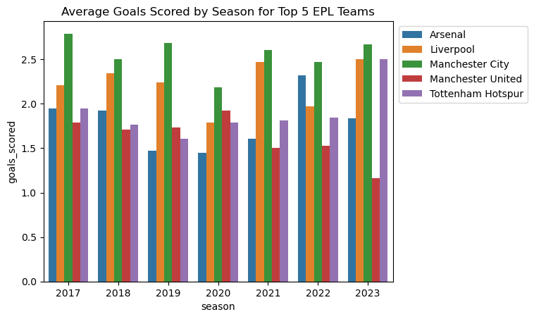

```python
### Seasonally scored goals on average for top 5:
sb.barplot(x = t2["season"], y = t2["goals_scored"], hue = "team", data= t2)
plt.title('Average Goals Scored by Season for Top 5 EPL Teams')
plt.legend(loc='upper right', bbox_to_anchor=(1.4, 1))
plt.show()
```

### Description

On average, it seems that Manchester City, compared to the other top5 teams, is able to maintain the highest seasonal goals scored from one year to the next.

In 2023, it looks like Tottenham Hotspuris competing fiercely, ranking 2nd on average, as opposed to previous years where it was third or fourth. Liverpool is a strong competitor against Manchester City (1st team) and is ranking either 2nd or 3rd at most.

The average goals scored of Manchester United looks like they are decreasing over time. In the last three years, it is even raking the last among the Top 5.

## 4. Identifying Overperforming Football Teams Based on Goals Scored and Expected Goals (xG)

### Introduction

In the realm of football analytics, Expected Goals (xG) has emerged as a pivotal metric for evaluating team performance. xG quantifies the likelihood of a shot resulting in a goal, taking into account numerous factors like shot location, type, and defensive pressure. Assessing how a team performs relative to their xG provides crucial insights into their offensive efficiency.

### Objective

This analysis seeks to identify overperforming football teams by contrasting their Goals Scored with Expected Goals (xG). Overperforming teams consistently score more goals than their xG projections suggest. The analysis is divided into two main parts:

### Part 1: Identifying Top 5 Overperforming Teams Each Year

In this segment, we dissect individual football seasons to pinpoint teams that have excelled in surpassing their xG projections. The process involves calculating Goals Scored and xG for each team within a season and identifying the top 5 teams with the highest positive differences between Goals Scored and xG.

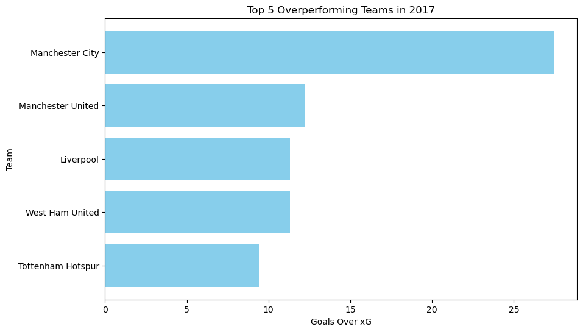

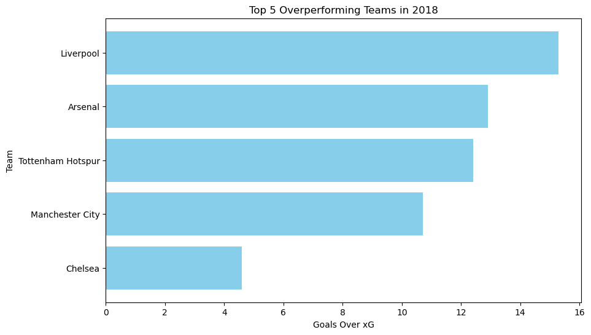

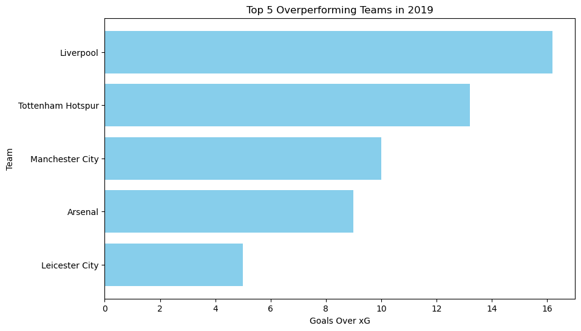

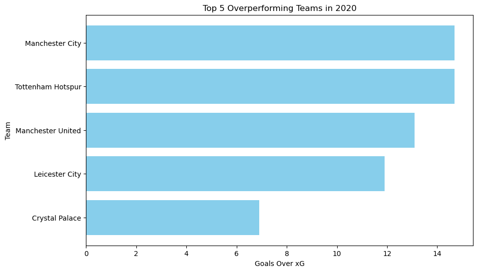

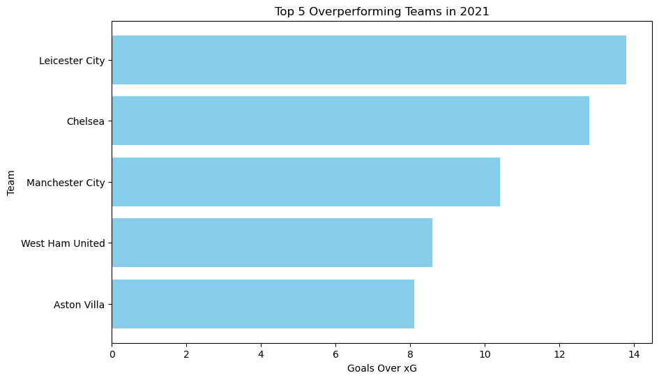

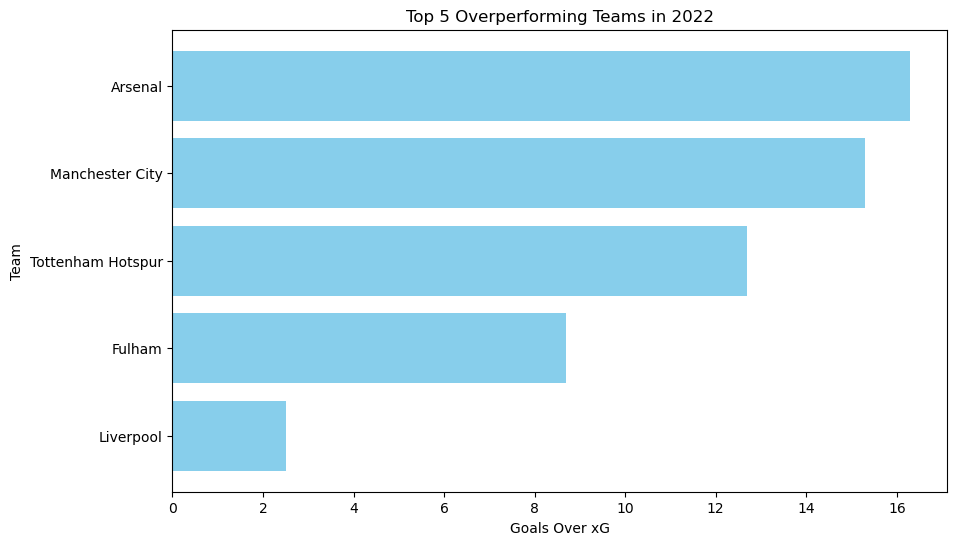

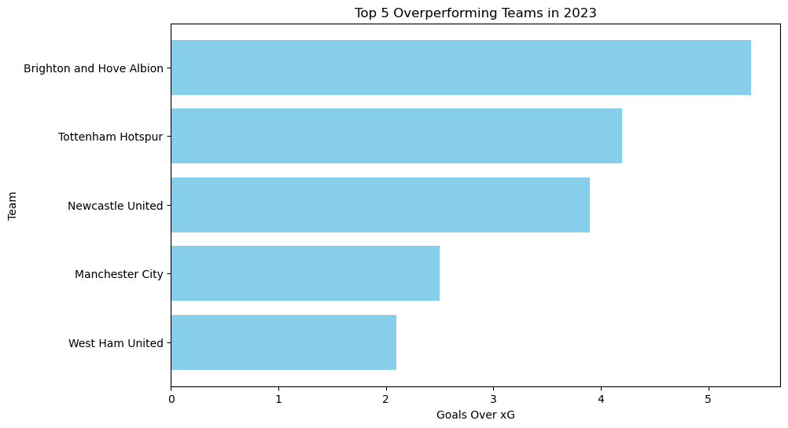

```python
df['goals_over_xG'] = df['goals_scored'] - df['expected_goals']

# Group data by year (season) and team, and calculate the total goals over xG
grouped = df.groupby(['season', 'team'])['goals_over_xG'].sum().reset_index()

# Sort the data by season and goals over xG in descending order
sorted_data = grouped.sort_values(by=['season', 'goals_over_xG'], ascending=[True, False])

# Get the top 5 overperforming teams for each year
top_teams = sorted_data.groupby('season').head(5)

# Create visualizations for each year
for year, group in top_teams.groupby('season'):
    plt.figure(figsize=(10, 6))
    plt.barh(group['team'], group['goals_over_xG'], color='skyblue')
    plt.xlabel('Goals Over xG')
    plt.ylabel('Team')
    plt.title(f'Top 5 Overperforming Teams in {year}')
    plt.gca().invert_yaxis()  # Reverse the order of teams for better visualization
    plt.show()
```

### Part 2: Identifying Top 5 Overperforming Teams Combined for All Seasons

Here, we aggregate data across multiple seasons to spot teams that have consistently outperformed their xG expectations. We compute the cumulative Goals Scored and xG for each team across all seasons and ascertain the teams with the greatest collective positive differences between Goals Scored and xG.

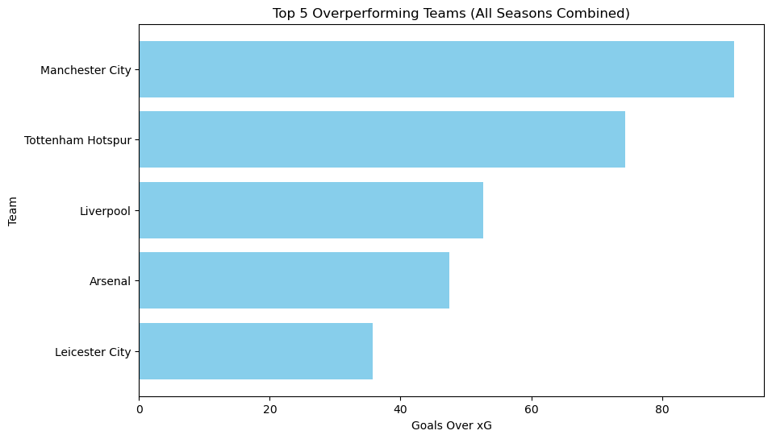

```python
grouped = df.groupby('team')['goals_over_xG'].sum().reset_index()

# Sort the data by goals over xG in descending order
sorted_data = grouped.sort_values(by='goals_over_xG', ascending=False)

# Get the top 5 overperforming teams for all seasons combined
top_teams = sorted_data.head(5)

# Create a visualization for the top overperforming teams
plt.figure(figsize=(10, 6))
plt.barh(top_teams['team'], top_teams['goals_over_xG'], color='skyblue')
plt.xlabel('Goals Over xG')
plt.ylabel('Team')
plt.title('Top 5 Overperforming Teams (All Seasons Combined)')
plt.gca().invert_yaxis()  # Reverse the order of teams for better visualization
plt.show()
```

### Description

Both parts of the analysis incorporate visualizations in the form of bar charts. These charts showcase the top overperforming teams for each season (Part 1) and the top overperforming teams across all seasons (Part 2). They provide a clear representation of which teams have consistently demonstrated superior goal-scoring capabilities in relation to their xG expectations.

Manchester City has the most goals over xG which is somewhat expected as they scored the most goals.

Now, let's analyse it differently.

## Using Percentage Terms for Overperformance Analysis

In our ongoing analysis, we have made a significant adjustment in the way we assess teams' overperformance relative to Expected Goals (xG). Rather than relying solely on total overperformance values, we have transitioned to using percentage terms. This shift offers a more meaningful and equitable basis for comparison across seasons and teams. Here's why percentage terms are a better choice for comparison:

**1. Standardized Assessment:** Total overperformance values may be influenced by the volume of scoring opportunities a team encounters in a given season. Teams with more opportunities are likely to have higher total overperformance figures. By calculating percentage overperformance, we standardize the assessment, enabling fair comparisons irrespective of variations in opportunities.

**2. Reflecting Efficiency:** Percentage overperformance provides insights into a team's efficiency in front of the goal. It gauges a team's ability to make the most of the opportunities they create, which is a key indicator of offensive prowess.

**3. Comparative Analysis:** Using percentage terms allows us to evaluate teams on a level playing field, making it easier to identify consistent overperformers across different seasons. This approach helps us pinpoint teams that consistently excel in converting opportunities into goals, regardless of the total number of chances.

Now, let's proceed to examine the results of our analysis using percentage terms for overperformance:

### Part 1: Identifying Top 5 Overperforming Teams Each Year (Percentage Terms)

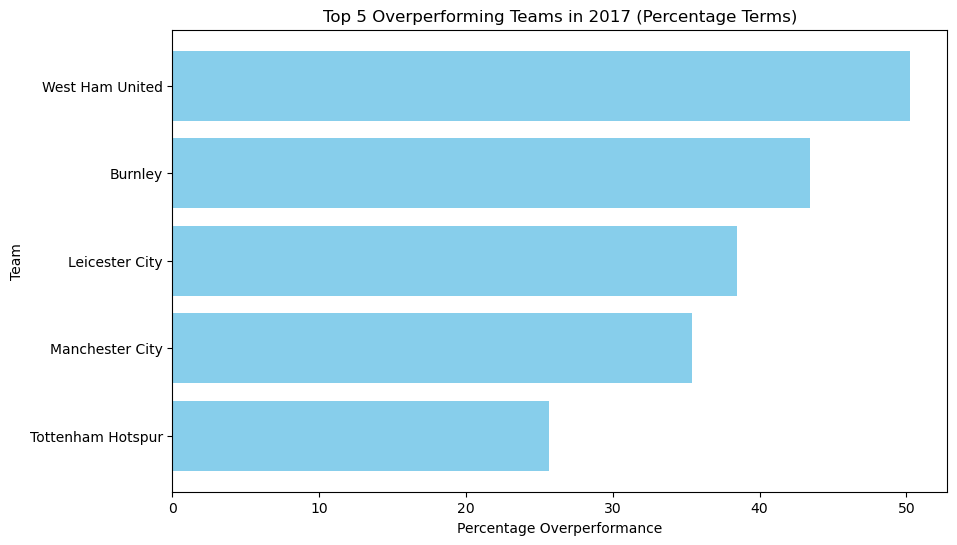

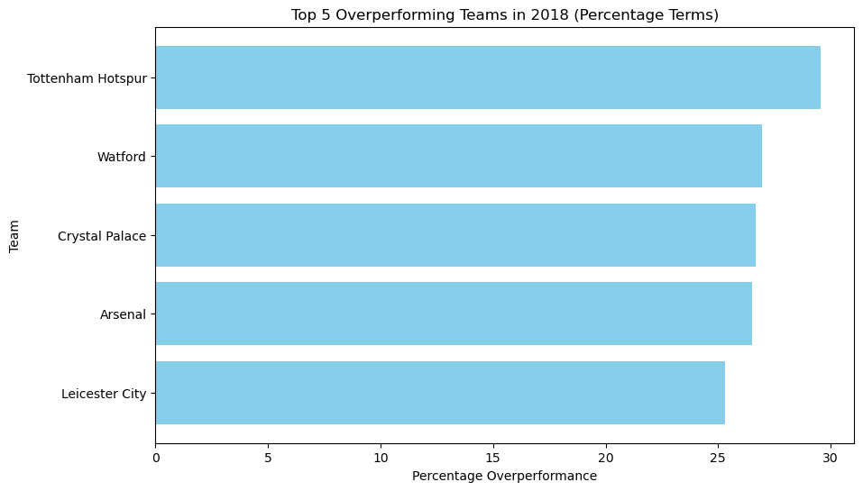

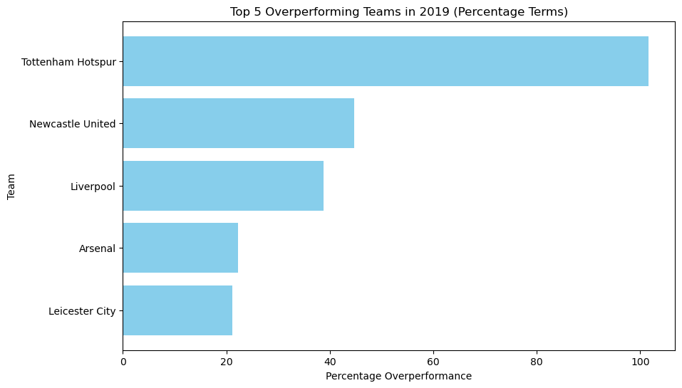

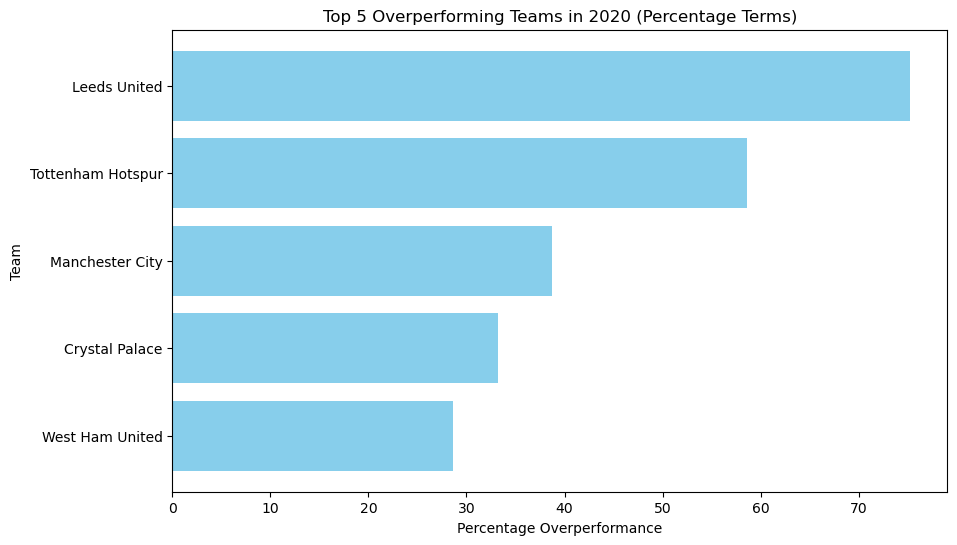

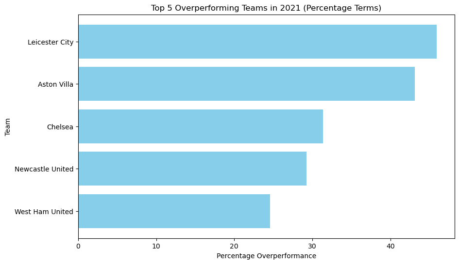

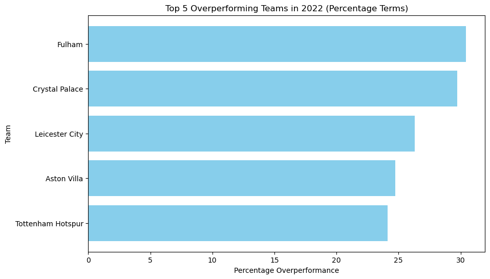

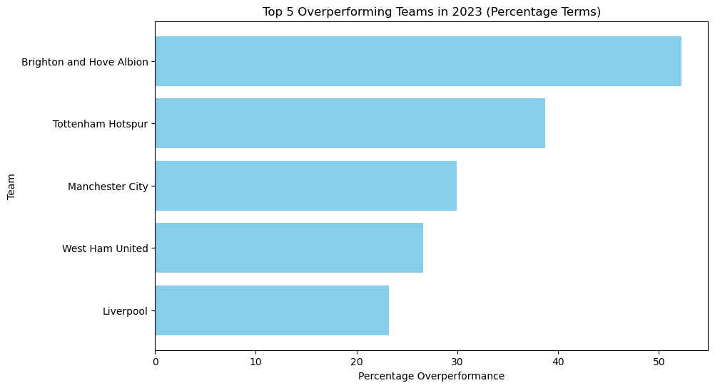

```python
df['percentage_overperformance'] = ((df['goals_scored'] - df['expected_goals']) / df['expected_goals']) * 100

# Group data by year (season) and team, and calculate the mean percentage overperformance
grouped = df.groupby(['season', 'team'])['percentage_overperformance'].mean().reset_index()

# Sort the data by season and percentage overperformance in descending order
sorted_data = grouped.sort_values(by=['season', 'percentage_overperformance'], ascending=[True, False])

# Get the top 5 overperforming teams for each year
top_teams = sorted_data.groupby('season').head(5)

# Create visualizations for the top overperforming teams
for year, group in top_teams.groupby('season'):
    plt.figure(figsize=(10, 6))
    plt.barh(group['team'], group['percentage_overperformance'], color='skyblue')
    plt.xlabel('Percentage Overperformance')
    plt.ylabel('Team')
    plt.title(f'Top 5 Overperforming Teams in {year} (Percentage Terms)')
    plt.gca().invert_yaxis()  # Reverse the order of teams for better visualization
    plt.show()
```

### Part 2: Identifying Top 5 Overperforming Teams Combined for All Seasons (Percentage Terms)

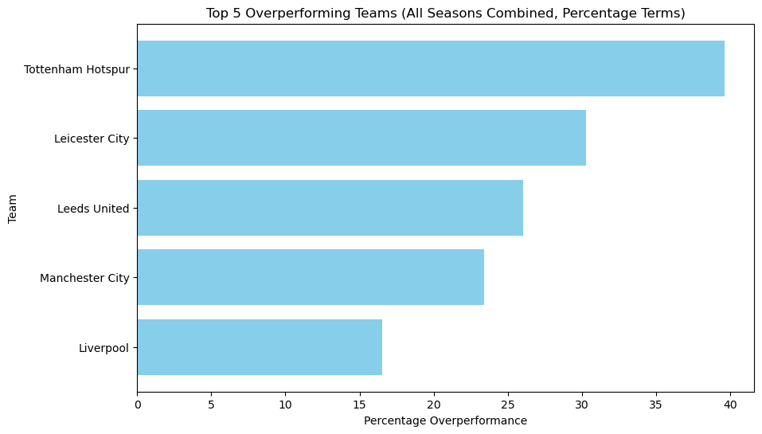

```python
df['percentage_overperformance'] = ((df['goals_scored'] - df['expected_goals']) / df['expected_goals']) * 100

# Group data by team and calculate the mean percentage overperformance
grouped = df.groupby('team')['percentage_overperformance'].mean().reset_index()

# Sort the data by percentage overperformance in descending order
sorted_data = grouped.sort_values(by='percentage_overperformance', ascending=False)

# Get the top 5 overperforming teams for all seasons combined
top_teams = sorted_data.head(5)

# Create a visualization for the top overperforming teams
plt.figure(figsize=(10, 6))
plt.barh(top_teams['team'], top_teams['percentage_overperformance'], color='skyblue')
plt.xlabel('Percentage Overperformance')
plt.ylabel('Team')
plt.title('Top 5 Overperforming Teams (All Seasons Combined, Percentage Terms)')
plt.gca().invert_yaxis()  # Reverse the order of teams for better visualization
plt.show()
```

### Description

We can see that Tottenhan Hotspur makes the most of their chances as their percentage overperformance is close to 40%.

This shift to percentage terms provides us with a more insightful and standardized approach to evaluating teams' offensive efficiency. It allows us to recognize teams that consistently excel in goal-scoring, regardless of the fluctuations in opportunities across different seasons. Ultimately, this method enhances our ability to identify patterns of success and assess team performance more comprehensively in the dynamic landscape of football analytics.

Incorporating percentage terms for overperformance analysis not only standardizes the assessment but also highlights teams' efficiency in converting opportunities into goals. It enables fair comparisons across seasons and teams, shedding light on consistent overperformers. This shift enhances the depth and accuracy of our analysis, providing a more holistic view of team performance in the realm of football analytics.

## Conclusion

In conclusion, Manchester City maintains dominance with consistent high goal-scoring and a strong home advantage. Arsenal and Tottenham show steady improvement, while Manchester United's performance fluctuates. Liverpool's scoring is inconsistent, Tottenham converts chances very efficiently and Brighton and Hove Albion make a notable appearance. These trends highlight the dynamic nature of Premier League competition from 2019 to 2022.